# Predicting Hotel Booking Cancellations

Author

Trung Nghia Vo, Misha Shen, Nathan Li, Anushka Seth

Published

November 19, 2026

```python
# Standard library
import shutil
from pathlib import Path

# Third-party libraries
import kagglehub
import pandas as pd
import numpy as np
from scipy.sparse import csr_matrix
from IPython.display import display

# Scikit-learn: Base utilities
from sklearn.base import clone

# Scikit-learn: Data preprocessing
from sklearn.compose import ColumnTransformer
from sklearn.impute import SimpleImputer
from sklearn.pipeline import make_pipeline
from sklearn.preprocessing import OneHotEncoder, StandardScaler

# Scikit-learn: Models
from sklearn.dummy import DummyClassifier
from sklearn.linear_model import LogisticRegression

# Scikit-learn: Model selection
from sklearn.model_selection import train_test_split, cross_validate, cross_val_predict

# Scikit-learn: Evaluation metrics and visualization
from sklearn.metrics import (
    accuracy_score,
    precision_score,
    recall_score,
    f1_score,
    roc_auc_score,
    average_precision_score,
    make_scorer,
    ConfusionMatrixDisplay,
    RocCurveDisplay,
)
```

# Summary

# Introduction

Hotel cancellations create uncertainty for room inventory, staffing, and revenue management. When a booking is cancelled after an inventory decision or guest-arrival plan has been made, the hotel may lose a room opportunity or spend resources on guests who are unlikely to cancel. A useful cancellation-prediction model could flag high-risk reservations for targeted communication, revised deposit or payment policies, or a carefully managed overbooking strategy. The value of such a model depends on both its ability to rank bookings by risk and the consequences of any intervention, because not every hotel action is appropriate for every false alarm.

This report answers the following question: **Can booking information available at reservation time predict whether a hotel booking will be cancelled, and how does changing the decision threshold affect the usefulness of the prediction?** The question is actionable if the response variable is available for past bookings and the predictors are available before cancellation occurs. It is measurable with the available data because the response is a binary cancellation indicator and the predictors describe individual reservations.

The Hotel Booking Demand dataset was originally published by Antonio, Almeida, and Nunes and is publicly distributed through Kaggle [1,2]. Each row represents one booking made for a city hotel or resort hotel. The original source contains 119,390 rows and variables describing booking timing, length of stay, guest composition, deposit and market information, previous cancellations, and customer characteristics [1,2]. The variables used in this analysis describe information available at or near the booking stage, while the following variables were excluded: reservation status and reservation status date reveal the final outcome; assigned room type, booking changes, and days in waiting list may reflect events after the initial booking. The target variable is whether the booking was cancelled, coded as 1 for cancellation and 0 for no cancellation. The target supports binary classification and is not evenly balanced: 44,224 bookings, or 37.0%, were cancelled. These features and the target are sufficient to evaluate whether past patterns can predict cancellation in a held-out booking sample.

# Methods

## Overview of the analysis

The goal of this analysis is to predict whether a hotel booking will be cancelled (`is_canceled`) using information available about the booking. We used the Hotel Booking Demand dataset from Kaggle, which contains 119,390 bookings from a city hotel and a resort hotel. Of these, 44,224 (37.0%) were cancelled and 75,166 (63.0%) were not.

We first removed five columns. `reservation_status` and `reservation_status_date` record the outcome of the booking itself, so keeping them would let the model “see” the answer (target leakage). `assigned_room_type`, `booking_changes` and `days_in_waiting_list` are recorded after the booking is made, so they would not be available when predicting whether a new booking will cancel. The remaining 26 predictors were prepared as follows: missing values in numeric columns were replaced with the median and the columns were standardized, missing values in categorical columns were labelled “Unknown” and the columns were one-hot encoded, and the `agent` and `company` ID columns were treated as categories, with missing IDs coded as -1. After encoding there were 929 features.

We then split the data into 80% training (95,512 bookings) and 20% test (23,878 bookings), stratified by the target so both sets keep the 37% cancellation rate. All preprocessing was placed inside a scikit-learn pipeline together with the classifier, so imputation, scaling and encoding are learned from training data only and the test set cannot influence them. The test set was kept untouched until the very end.

The remaining steps were:

1. Fit a baseline model and a logistic regression model and compare them using 5-fold cross-validation on the training set.
2. Select the final model using the cross-validation results only.
3. Choose a decision threshold using out-of-fold predictions on the training set.
4. Evaluate the final model once on the held-out test set.

## Evaluation metrics

We report accuracy, precision, recall, F1, ROC-AUC and average precision (AP), but different metrics play different roles:

- **Average precision (primary metric for model selection).** The practical use of this model is to flag bookings that are likely to cancel so the hotel can act on them. AP summarizes the trade-off between precision (how many flagged bookings really cancel) and recall (how many cancellations we catch) across all possible thresholds, and it focuses on the cancellation class. It does not depend on a particular threshold, so it measures how well the model ranks bookings by risk. Because the baseline’s AP equals the positive rate (0.370), it also has an easy-to-read reference point.
- **F1 (metric for choosing the threshold).** Once the model ranks bookings, we must decide how high the predicted probability has to be before a booking is flagged. We chose the threshold that maximizes F1, which weights precision and recall equally. This is a neutral assumption, because we do not have the hotel’s actual costs of a missed cancellation versus a false alarm.
- **Precision, recall, ROC-AUC and accuracy (supporting metrics).** Precision and recall show the two kinds of error directly. ROC-AUC is reported as a second threshold-free measure of ranking quality. With a 37% positive rate it is not badly inflated, so it agrees with AP. Accuracy is reported for completeness, but it is a weak headline metric here because the do-nothing baseline already reaches 63.0%.

## Download raw data

```python
root = Path.cwd().resolve()
if root.name == "analysis":
    root = root.parent

raw_dir = root / "data" / "raw"
processed_dir = root / "data" / "processed"

raw_dir.mkdir(parents=True, exist_ok=True)
processed_dir.mkdir(parents=True, exist_ok=True)


download_dir = Path(
    kagglehub.dataset_download("jessemostipak/hotel-booking-demand")
)

shutil.copyfile(
    download_dir / "hotel_bookings.csv",
    raw_dir / "hotel_bookings.csv",
)

df = pd.read_csv(raw_dir / "hotel_bookings.csv")
```

```
Downloading to /root/.cache/kagglehub/datasets/jessemostipak/hotel-booking-demand/1.archive...
```

```
Extracting files...
```

## Process data

```python
df = df.drop(columns=[
    "reservation_status",
    "reservation_status_date",
    "assigned_room_type",
    "booking_changes",
    "days_in_waiting_list",
])


X = df.drop(columns="is_canceled").copy()
y = df["is_canceled"].reset_index(drop=True)


for col in ["agent", "company"]:
    X[col] = X[col].fillna(-1).astype(int).astype(str)

numeric_cols = X.select_dtypes(include="number").columns.tolist()
categorical_cols = X.select_dtypes(exclude="number").columns.tolist()


numeric_pipe = make_pipeline(
    SimpleImputer(strategy="median"),
    StandardScaler(),
)


categorical_pipe = make_pipeline(
    SimpleImputer(strategy="constant", fill_value="Unknown"),
    OneHotEncoder(handle_unknown="ignore"),
)

preprocessor = ColumnTransformer(
    transformers=[
        ("numeric", numeric_pipe, numeric_cols),
        ("categorical", categorical_pipe, categorical_cols),
    ],
    sparse_threshold=1.0,
)

X_processed = preprocessor.fit_transform(X)

df_processed = pd.DataFrame.sparse.from_spmatrix(
    csr_matrix(X_processed),
    columns=preprocessor.get_feature_names_out(),
)


df_processed["is_canceled"] = y


output_file = processed_dir / "hotel_bookings_processed.csv"

df_processed.to_csv(
    output_file,
    index=False,
    chunksize=1000,
)

print("Processed shape:", df_processed.shape)
df_processed.head()
```

```
Processed shape: (119390, 930)
```

|  | numeric__lead_time | numeric__arrival_date_year | numeric__arrival_date_week_number | numeric__arrival_date_day_of_month | numeric__stays_in_weekend_nights | numeric__stays_in_week_nights | numeric__adults | numeric__children | numeric__babies | numeric__is_repeated_guest | ... | categorical__company_92 | categorical__company_93 | categorical__company_94 | categorical__company_96 | categorical__company_99 | categorical__customer_type_Contract | categorical__customer_type_Group | categorical__customer_type_Transient | categorical__customer_type_Transient-Party | is_canceled |
| --- | --- | --- | --- | --- | --- | --- | --- | --- | --- | --- | --- | --- | --- | --- | --- | --- | --- | --- | --- | --- | --- |
| 0 | 2.227051 | -1.634768 | -0.012141 | -1.685297 | -0.92889 | -1.31024 | 0.247897 | -0.260659 | -0.081579 | -0.18156 | ... | 0.0 | 0.0 | 0.0 | 0.0 | 0.0 | 0.0 | 0.0 | 1.0 | 0.0 | 0 |
| 1 | 5.923385 | -1.634768 | -0.012141 | -1.685297 | -0.92889 | -1.31024 | 0.247897 | -0.260659 | -0.081579 | -0.18156 | ... | 0.0 | 0.0 | 0.0 | 0.0 | 0.0 | 0.0 | 0.0 | 1.0 | 0.0 | 0 |
| 2 | -0.907814 | -1.634768 | -0.012141 | -1.685297 | -0.92889 | -0.786207 | -1.478447 | -0.260659 | -0.081579 | -0.18156 | ... | 0.0 | 0.0 | 0.0 | 0.0 | 0.0 | 0.0 | 0.0 | 1.0 | 0.0 | 0 |
| 3 | -0.851667 | -1.634768 | -0.012141 | -1.685297 | -0.92889 | -0.786207 | -1.478447 | -0.260659 | -0.081579 | -0.18156 | ... | 0.0 | 0.0 | 0.0 | 0.0 | 0.0 | 0.0 | 0.0 | 1.0 | 0.0 | 0 |
| 4 | -0.842309 | -1.634768 | -0.012141 | -1.685297 | -0.92889 | -0.262174 | 0.247897 | -0.260659 | -0.081579 | -0.18156 | ... | 0.0 | 0.0 | 0.0 | 0.0 | 0.0 | 0.0 | 0.0 | 1.0 | 0.0 | 0 |

5 rows × 930 columns

## Classification analysis

```python
RANDOM_STATE = 42
```

### Train/test split

```python
X_train, X_test, y_train, y_test = train_test_split(
    X, y, test_size=0.2, stratify=y, random_state=RANDOM_STATE
)
print(f"Train: {X_train.shape}, Test: {X_test.shape}")
print(f"Cancellation rate (train): {y_train.mean():.3f}")
```

```
Train: (95512, 26), Test: (23878, 26)
Cancellation rate (train): 0.370
```

### Exploratory analysis of the training set

These descriptive plots use only `X_train` and `y_train`. They show the class balance and how cancellations vary by lead time, deposit type, hotel, and arrival month.

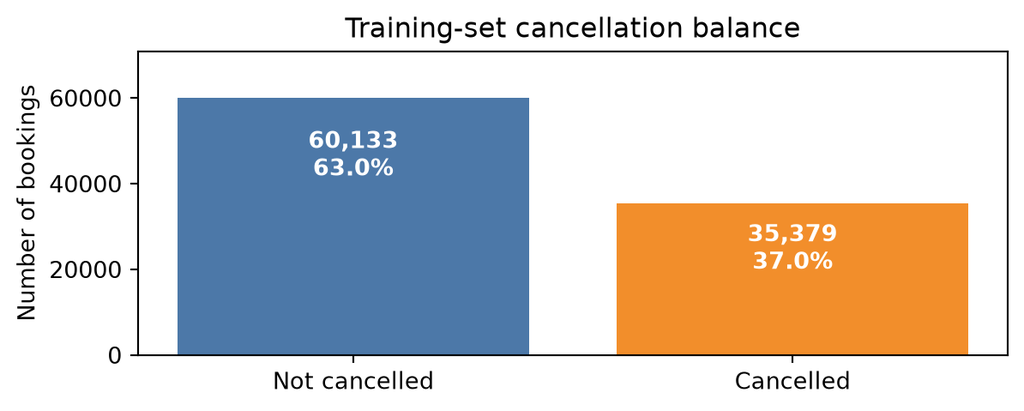

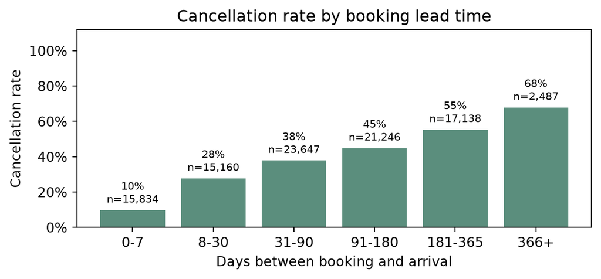

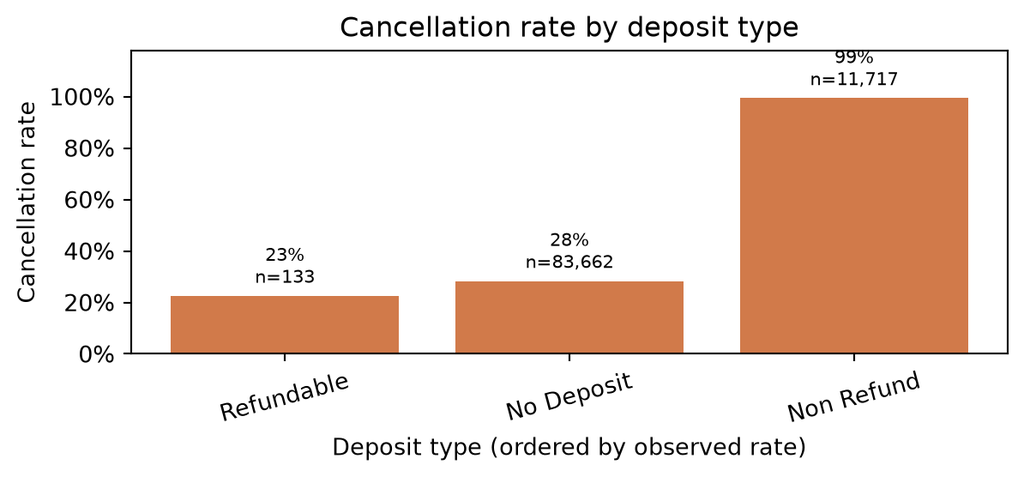

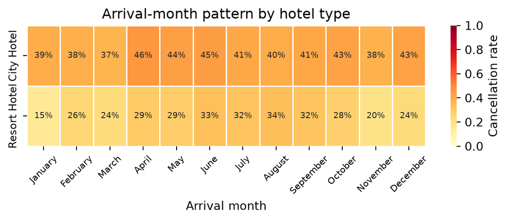

```python
import matplotlib.pyplot as plt
import seaborn as sns
from matplotlib.ticker import PercentFormatter

train_eda = pd.concat(
    [
        X_train.reset_index(drop=True),
        y_train.reset_index(drop=True).rename("is_canceled"),
    ],
    axis=1,
)

lead_time_labels = ["0-7", "8-30", "31-90", "91-180", "181-365", "366+"]
train_eda["lead_time_band"] = pd.cut(
    train_eda["lead_time"],
    bins=[-1, 7, 30, 90, 180, 365, np.inf],
    labels=lead_time_labels,
)

month_order = [
    "January", "February", "March", "April", "May", "June",
    "July", "August", "September", "October", "November", "December",
]
train_eda["arrival_date_month"] = pd.Categorical(
    train_eda["arrival_date_month"],
    categories=month_order,
    ordered=True,
)

status_counts = train_eda["is_canceled"].value_counts().reindex([0, 1])
status_shares = status_counts / status_counts.sum()
lead_summary = (
    train_eda.groupby("lead_time_band", observed=True)
    .agg(
        cancellation_rate=("is_canceled", "mean"),
        bookings=("is_canceled", "size"),
    )
    .reset_index()
)
deposit_summary = (
    train_eda.groupby("deposit_type", observed=True)
    .agg(
        cancellation_rate=("is_canceled", "mean"),
        bookings=("is_canceled", "size"),
    )
    .reset_index()
    .sort_values("cancellation_rate")
)
monthly_rates = (
    train_eda.groupby(["hotel", "arrival_date_month"], observed=True)["is_canceled"]
    .mean()
    .unstack()
    .reindex(index=["City Hotel", "Resort Hotel"], columns=month_order)
)

fig, ax = plt.subplots(figsize=(6.3, 2.6))
status_bars = ax.bar(
    ["Not cancelled", "Cancelled"],
    status_counts.values,
    color=["#4C78A8", "#F28E2B"],
)
ax.set_title("Training-set cancellation balance")
ax.set_ylabel("Number of bookings")
ax.set_ylim(0, status_counts.max() * 1.18)
for bar, share in zip(status_bars, status_shares):
    ax.text(
        bar.get_x() + bar.get_width() / 2,
        bar.get_height() * 0.88,
        f"{int(bar.get_height()):,}\n{share:.1%}",
        ha="center",
        va="top",
        color="white",
        fontweight="bold",
    )
fig.tight_layout()
plt.show()

fig, ax = plt.subplots(figsize=(6.3, 3))
lead_bars = ax.bar(
    lead_summary["lead_time_band"].astype(str),
    lead_summary["cancellation_rate"],
    color="#5B8E7D",
)
ax.set_title("Cancellation rate by booking lead time")
ax.set_xlabel("Days between booking and arrival")
ax.set_ylabel("Cancellation rate")
ax.set_ylim(0, 1.12)
ax.set_yticks(np.linspace(0, 1, 6))
ax.yaxis.set_major_formatter(PercentFormatter(xmax=1))
for bar, row in zip(lead_bars, lead_summary.itertuples()):
    ax.annotate(
        f"{row.cancellation_rate:.0%}\nn={row.bookings:,}",
        (bar.get_x() + bar.get_width() / 2, bar.get_height()),
        ha="center",
        va="bottom",
        fontsize=8,
        xytext=(0, 3),
        textcoords="offset points",
    )
fig.tight_layout()
plt.show()

fig, ax = plt.subplots(figsize=(6.3, 3))
deposit_bars = ax.bar(
    deposit_summary["deposit_type"],
    deposit_summary["cancellation_rate"],
    color="#D17A4A",
)
ax.set_title("Cancellation rate by deposit type")
ax.set_xlabel("Deposit type (ordered by observed rate)")
ax.set_ylabel("Cancellation rate")
ax.set_ylim(0, 1.18)
ax.set_yticks(np.linspace(0, 1, 6))
ax.yaxis.set_major_formatter(PercentFormatter(xmax=1))
ax.tick_params(axis="x", rotation=15)
for bar, row in zip(deposit_bars, deposit_summary.itertuples()):
    ax.annotate(
        f"{row.cancellation_rate:.0%}\nn={row.bookings:,}",
        (bar.get_x() + bar.get_width() / 2, bar.get_height()),
        ha="center",
        va="bottom",
        fontsize=8,
        xytext=(0, 3),
        textcoords="offset points",
    )
fig.tight_layout()
plt.show()

fig, ax = plt.subplots(figsize=(6.5, 2.8))
sns.heatmap(
    monthly_rates,
    cmap="YlOrRd",
    vmin=0,
    vmax=1,
    annot=True,
    fmt=".0%",
    annot_kws={"fontsize": 7},
    linewidths=0.5,
    cbar_kws={"label": "Cancellation rate"},
    ax=ax,
)
ax.set_title("Arrival-month pattern by hotel type")
ax.set_xlabel("Arrival month")
ax.set_ylabel("")
ax.tick_params(axis="x", rotation=45, labelsize=8)
ax.tick_params(axis="y", labelsize=9)

fig.tight_layout()
plt.show()
```

**Figure 1. Training-set cancellation balance.** The plot compares the number and percentage of cancelled and not-cancelled bookings in the 80% training partition.

**Figure 2. Cancellation rate by booking lead time.** The bars show the observed cancellation rate within each lead-time interval.

**Figure 3. Cancellation rate by deposit type.** The bars compare observed cancellation rates across deposit categories.

**Figure 4. Arrival-month cancellation pattern by hotel type.** The heatmap shows cancellation rates for each arrival month in both hotel categories.

### Models

We compared two models:

- **Baseline (majority-class dummy classifier).** This predicts “not cancelled” for every booking. It does not learn anything, but it gives a floor that any useful model must beat, and it shows why accuracy alone is misleading here (it already scores 63.0%).
- **Logistic regression.** This is a standard, well-understood classifier for a binary outcome. It outputs a probability of cancellation for each booking, which we need in order to rank bookings by risk and to adjust the decision threshold. It trains quickly even with about 930 features, and its coefficients show which booking characteristics raise or lower cancellation risk, which makes the results easier to explain to a hotel manager. We used it as our main model because it is a strong, interpretable starting point for a tabular problem with many categorical variables.

```python
models = {
    "Dummy (majority class)": make_pipeline(
        clone(preprocessor),
        DummyClassifier(strategy="most_frequent"),
    ),
    "Logistic Regression": make_pipeline(
        clone(preprocessor),
        LogisticRegression(max_iter=1000, random_state=RANDOM_STATE),
    ),
}
```

### Cross-validated comparison (training set only)

```python
scoring = {
    "accuracy": "accuracy",
    "precision": make_scorer(precision_score, zero_division=0),
    "recall": "recall",
    "f1": make_scorer(f1_score, zero_division=0),
    "roc_auc": "roc_auc",
    "average_precision": "average_precision",
}

cv_rows = []
for name, model in models.items():
    res = cross_validate(model, X_train, y_train, cv=5, scoring=scoring)
    row = {"model": name}
    row.update({m: res[f"test_{m}"].mean() for m in scoring})
    cv_rows.append(row)

cv_results = pd.DataFrame(cv_rows).set_index("model").round(3)
cv_results
```

| model | accuracy | precision | recall | f1 | roc_auc | average_precision |
| --- | --- | --- | --- | --- | --- | --- |
| Dummy (majority class) | 0.630 | 0.000 | 0.0 | 0.000 | 0.500 | 0.370 |
| Logistic Regression | 0.827 | 0.806 | 0.7 | 0.749 | 0.908 | 0.868 |

Table 1. 5-fold cross-validation results on the training set

### Visualizing cross-validation performance

These mean scores are computed from cross-validation on the training set. Average precision is the model-selection metric; F1 is shown at the default threshold of 0.5.

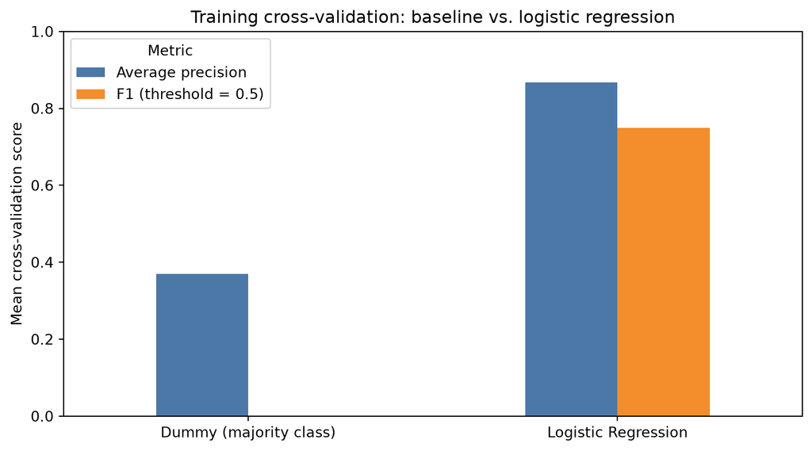

```python
fig, ax = plt.subplots(figsize=(8, 4.5))
cv_results[["average_precision", "f1"]].plot(
    kind="bar",
    color=["#4C78A8", "#F28E2B"],
    ax=ax,
)
ax.set_title("Training cross-validation: baseline vs. logistic regression")
ax.set_xlabel("")
ax.set_ylabel("Mean cross-validation score")
ax.set_ylim(0, 1)
ax.legend(["Average precision", "F1 (threshold = 0.5)"], title="Metric")
ax.tick_params(axis="x", rotation=0)
ax.grid(axis="x", visible=False)
fig.tight_layout()
plt.show()
```

**Figure 5. Training cross-validation performance.** The bars compare average precision and F1 across the five training folds for the baseline and logistic regression.

### Model Selection

```python
# Selection uses cross-validation only; the test set has not been touched yet.
selection_metric = "average_precision"

cv_best = cv_results[selection_metric].idxmax()
print(f"Selected model: {cv_best} "
      f"(CV {selection_metric} = {cv_results.loc[cv_best, selection_metric]:.3f})")

final_model = clone(models[cv_best])
```

```
Selected model: Logistic Regression (CV average_precision = 0.868)
```

### Threshold selection (training set only)

```python
# Out-of-fold predicted probabilities on the training set
oof_proba = cross_val_predict(
    final_model, X_train, y_train, cv=5, method="predict_proba"
)[:, 1]

rows = []
for t in np.arange(0.2, 0.81, 0.05).round(2):
    pred = (oof_proba >= t).astype(int)
    rows.append({
        "threshold": t,
        "precision": precision_score(y_train, pred, zero_division=0),
        "recall": recall_score(y_train, pred),
        "f1": f1_score(y_train, pred),
    })

threshold_table = pd.DataFrame(rows).set_index("threshold").round(3)
display(threshold_table)

threshold = threshold_table["f1"].idxmax()
print(f"Chosen threshold: {threshold}")
```

| threshold | precision | recall | f1 |
| --- | --- | --- | --- |
| 0.20 | 0.617 | 0.931 | 0.742 |
| 0.25 | 0.657 | 0.899 | 0.759 |
| 0.30 | 0.693 | 0.863 | 0.769 |
| 0.35 | 0.725 | 0.824 | 0.771 |
| 0.40 | 0.752 | 0.786 | 0.769 |
| 0.45 | 0.780 | 0.743 | 0.761 |
| 0.50 | 0.806 | 0.700 | 0.749 |
| 0.55 | 0.830 | 0.653 | 0.731 |
| 0.60 | 0.853 | 0.607 | 0.709 |
| 0.65 | 0.877 | 0.560 | 0.684 |
| 0.70 | 0.903 | 0.514 | 0.655 |
| 0.75 | 0.929 | 0.473 | 0.627 |
| 0.80 | 0.951 | 0.436 | 0.598 |

```
Chosen threshold: 0.35
```

Table 2. Scoring accross different thresholds (default is 0.5)

### Visualizing the training threshold trade-off

This plot uses out-of-fold predictions on the training set. The marker shows the threshold selected by training F1; it does not use the held-out test labels.

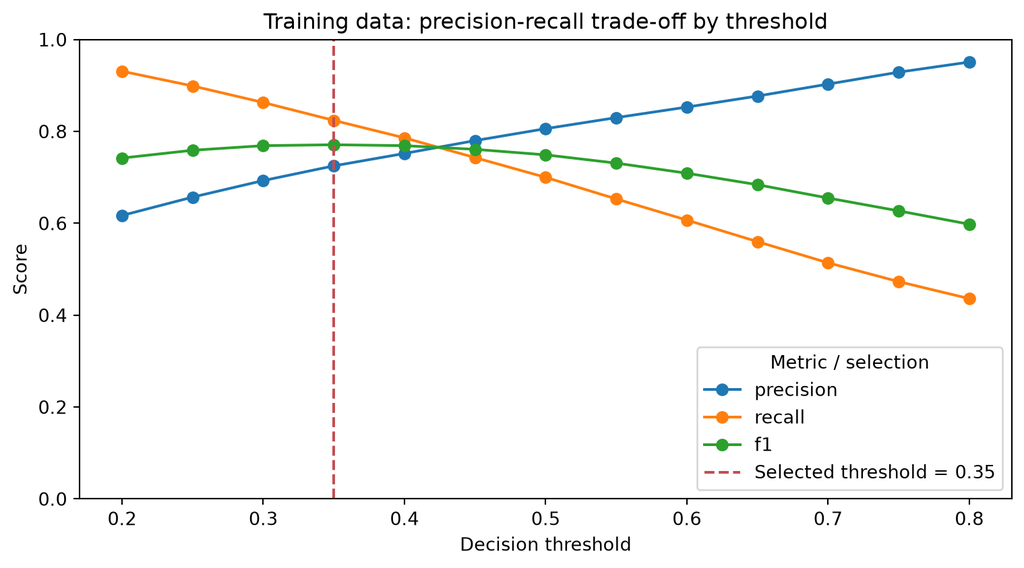

```python
fig, ax = plt.subplots(figsize=(8, 4.5))
threshold_table[["precision", "recall", "f1"]].plot(
    marker="o",
    ax=ax,
)
ax.axvline(
    threshold,
    color="#C44E52",
    linestyle="--",
    label=f"Selected threshold = {threshold:.2f}",
)
ax.set_title("Training data: precision-recall trade-off by threshold")
ax.set_xlabel("Decision threshold")
ax.set_ylabel("Score")
ax.set_ylim(0, 1)
ax.legend(title="Metric / selection")
ax.grid(axis="x", visible=False)
fig.tight_layout()
plt.show()
```

**Figure 6. Precision-recall trade-off across decision thresholds.** The plot uses out-of-fold training predictions, and the vertical marker shows the threshold selected by training F1.

### Final evaluation (held-out test set, used once)

```python
def evaluate(model, X, y, threshold=0.5):
    proba = model.predict_proba(X)[:, 1]
    pred = (proba >= threshold).astype(int)
    return {
        "accuracy": accuracy_score(y, pred),
        "precision": precision_score(y, pred, zero_division=0),
        "recall": recall_score(y, pred),
        "f1": f1_score(y, pred),
        "roc_auc": roc_auc_score(y, proba),
        "pr_auc": average_precision_score(y, proba),
    }

final_model.fit(X_train, y_train)
dummy = clone(models["Dummy (majority class)"]).fit(X_train, y_train)

test_results = pd.DataFrame({
    "Dummy (0.5)": evaluate(dummy, X_test, y_test),
    f"{cv_best} (0.5)": evaluate(final_model, X_test, y_test),
    f"{cv_best} ({threshold})": evaluate(final_model, X_test, y_test, threshold),
}).T.round(3)
test_results
```

|  | accuracy | precision | recall | f1 | roc_auc | pr_auc |
| --- | --- | --- | --- | --- | --- | --- |
| Dummy (0.5) | 0.630 | 0.000 | 0.000 | 0.000 | 0.500 | 0.370 |
| Logistic Regression (0.5) | 0.827 | 0.809 | 0.697 | 0.749 | 0.907 | 0.865 |
| Logistic Regression (0.35) | 0.819 | 0.726 | 0.818 | 0.770 | 0.907 | 0.865 |

Table 3. Final results on the held-out test set

# Results

Figures 1 through 4 summarize the training-set cancellation patterns that motivated the modelling analysis. Figure 1 establishes the class imbalance, while Figures 2 through 4 show how cancellation rates vary by lead time, deposit type, arrival month, and hotel type. Table 1 and Figure 5 compare the model candidates, and Table 2 and Figure 6 describe the threshold trade-off before the final held-out evaluation in Table 3.

The main finding is that booking attributes can support useful cancellation-risk ranking even though the majority-class baseline has misleadingly high accuracy. The held-out results show that the selected logistic regression model outperforms the baseline across the threshold-dependent and threshold-independent metrics, and that lowering the decision threshold changes the balance between missed cancellations and false alarms.

## Model comparison

Table 1 shows the 5-fold cross-validation results on the training set. The baseline reaches 63.0% accuracy only by predicting that no booking cancels, so its precision, recall and F1 are all 0, its ROC-AUC is 0.500 (no discrimination) and its AP of 0.370 equals the cancellation rate. Logistic regression is far better on every measure, with an AP of 0.868, a ROC-AUC of 0.908 and an F1 of 0.749. Because AP was our selection metric, logistic regression was selected as the final model.

## Best model

The best model is **logistic regression with a decision threshold of 0.35**. It clearly outperforms the baseline, generalizes well to unseen bookings, and catches about 82% of cancellations, compared with about 70% at the default threshold. The cost is more false alarms: about 27% of flagged bookings do not cancel, compared with about 19% at 0.5. We consider this a reasonable trade if an unsold room caused by a missed cancellation is more costly to the hotel than a flagged booking that turns out to show up. If the hotel instead wants to be more certain that flagged bookings will cancel, a higher threshold, such as 0.5, is more appropriate.

# Discussion

These results answer the stated question by showing that information available at booking time can identify likely cancellations, and that the useful threshold depends on the hotel’s operational priorities. The findings are consistent with the training patterns in Figures 1 through 4, where cancellation frequency varies across booking lead time, deposit type, and temporal or hotel characteristics. It was reasonable to expect some ranking advantage over the baseline because cancellation behavior differs across these booking attributes, although the size of the difference at held-out evaluation was favorable.

The real-world meaning is that a hotel could use the model to rank reservations by cancellation risk rather than making a binary decision about every booking. At the 0.5 threshold, the model catches fewer cancellations but is more certain that a flagged booking is likely to cancel. At 0.35, it catches more cancellations but also flags more bookings that remain active. This makes the threshold decision a business question: the hotel should prefer the lower threshold if a missed cancellation is more costly, and the higher threshold if unnecessary intervention or a false alarm is more costly.

## Limitations

- Only one model besides the baseline was compared, so we cannot say logistic regression is the best possible model. Logistic regression assumes linear effects on the log-odds and may miss interactions between features (for example, lead time and deposit type). A tree-based model such as gradient boosting is the natural next step.
- The threshold was chosen to maximize F1, which is an assumption of equal importance for precision and recall, not a cost derived from the hotel’s business.
- The dataset contains duplicate rows, and copies may appear in both the training and test sets, so the scores may be slightly optimistic.
- The data come from two hotels over a limited time period, and we used a random split rather than a time-based split. Performance on future bookings, or at other hotels, may be lower.

If deployed, the model could affect guest communication, staffing, inventory control, and revenue-management decisions. At a lower threshold, a hotel may contact more at-risk guests or hold inventory more conservatively, but it will also spend resources on bookings that would have remained active. A higher threshold reduces this false-alert burden but misses more cancellations. The appropriate operating point should therefore be based on documented cancellation costs and the cost of intervention, rather than F1 alone [4,5].

Future work could compare time-based validation with the random split, repeat the analysis after carefully removing duplicate records, and test nonlinear or cost-sensitive models. It could also estimate expected profit or room opportunity cost for each threshold, add pricing and inventory information, and evaluate whether the model remains accurate for a later period or a hotel outside this dataset [1,3,5].

# References

[1] Antonio, N., Almeida, A., & Nunes, L. (2019). Hotel booking demand datasets. *Data in Brief, 22*, 41-49. https://doi.org/10.1016/j.dib.2019.01.003

[2] Mostipak, J. (2020). Hotel booking demand. Kaggle. https://www.kaggle.com/datasets/jessemostipak/hotel-booking-demand

[3] Scikit-learn developers. (n.d.). Cross-validation: evaluating estimator performance. https://scikit-learn.org/stable/modules/cross_validation.html

[4] Scikit-learn developers. (n.d.). Logistic regression. https://scikit-learn.org/stable/modules/generated/sklearn.linear_model.LogisticRegression.html

[5] Hastie, T., Tibshirani, R., & Friedman, J. (2009). *The Elements of Statistical Learning: Data Mining, Inference, and Prediction* (2nd ed.). Springer. https://doi.org/10.1007/978-0-387-84858-7